# EODPlotter User Manual

## Source Code

https://github.com/msuefishlab/eodplotter

## Installation

EODPlotter is designed as an R package, to be installed using a package manager. EODPlotter is a command line alternative to the [TDMSViewer](https://github.com/msuefishlab/tdmsviewer)

We will install EODPlotter from github. Open RStudio and run

```r
install.packages('devtools')
```

This will install the devtools package which has the `install_github` function. Then run

```r
devtools::install_github('msuefishlab/eodplotter')
```

After running this it should install the EODViewer code and its dependencies automatically.

To install a specific version, e.g. the version mentioned in this guide, you can also run

```r
install_github('msuefishlab/eodplotter@0.0.4')
```

## Using EODPlotter as a command line tool

### Configure your command line

Add this line to your .bash_profile

```
export PATH=$PATH:`Rscript -e 'cat(paste0(.libPaths(),"/eodplotter/scripts",collapse=":"))'`:~/bin
```

### Process a TDMS file

First use `peak_finder` to find all EODs and outputs a new file, e.g. file.peaks.csv, which is named based on the input file (if you analyzed fish.tdms, it would output fish.peaks.csv)

```
peak_finder -f file.tdms -v
```

Then try using the `tdmsplot` command, it plots the raw signal as a graph, use to diagnose signal problems and view where EODs were called

[output not shown]

Finally analyze the signal and the peaks to produce output files

```
eodplot -f file.tdms -p file.peaks.csv
```

After running these commands you will have a number of files

- file.signal.png
- file.average.landmarks.png
- file.average.png
- file.all.png
- file.stats.csv
- file.landmarks.csv

Where file is the prefix of your TDMS file that you analyzed e.g. if it was fish123.tdms, then you would have fish123.stats.csv.

The file.stats.csv file contains useful information on duration and amplitude, and also number of EODs measured. Other files can be used for diagnosing issues with the analysis

### Process all files in parallel

This script will run the EOD analysis over all tdms files in a directory

```
parallel "peak_finder -f {}; tdmsplot -f {} -p {/}.peaks.csv; eodplot -f {} -p {/}.peaks.csv" ::: /path/to/files/*.tdms
```

### Combine all stats.csv

A helper script called combine_stats is added so after processing many TDMS files, simply run

```
combine_stats
```

This will output a combined stats file

### Summarize EOD results from different experiments

If you have different experiments with different timepoints and you want to compare them all then this script is an example of something you could try

This will plot the amplitude from multiple experiments where it assumes some particular file naming conventions e.g.

- 1_MOCntrl1_Baseline_2017_06_29_07_34_08.tdms
- 2_MOCntrl1_30_2017_06_29_08_21_23.tdms
- 3_MOCntrl1_60_2017_06_29_09_00_21.tdms

Generic pattern `<number>_MO<experimentname>_minutes_timestamp.tdms`

[output not shown]

Example output

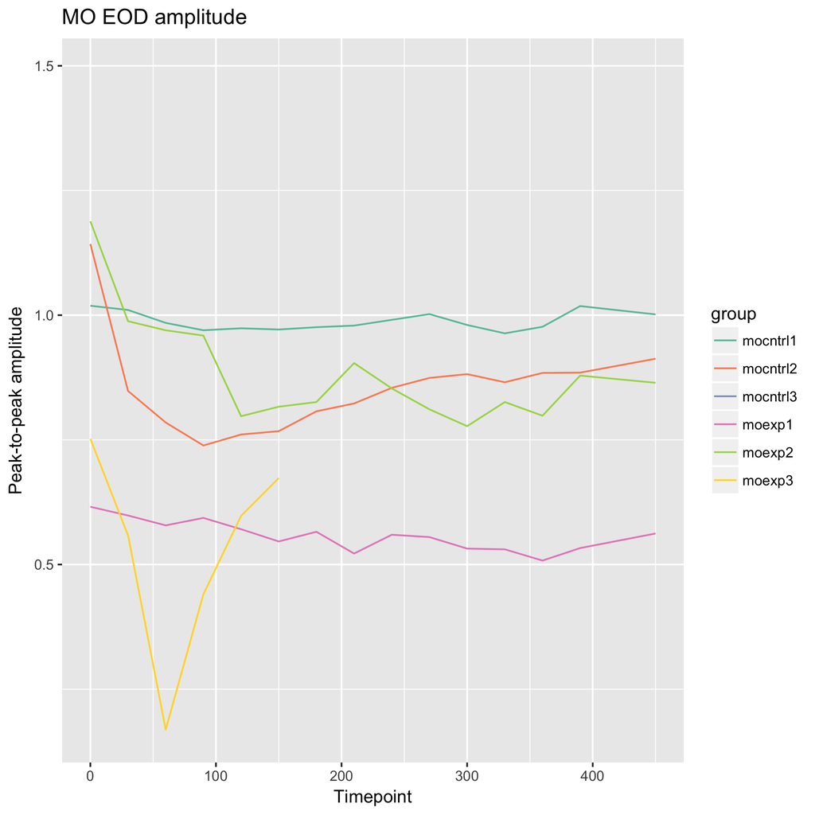

## Using EODPlotter as an R library

Load the library

```r
library(eodplotter)
```

Plot the raw signal of the data using plotTdms

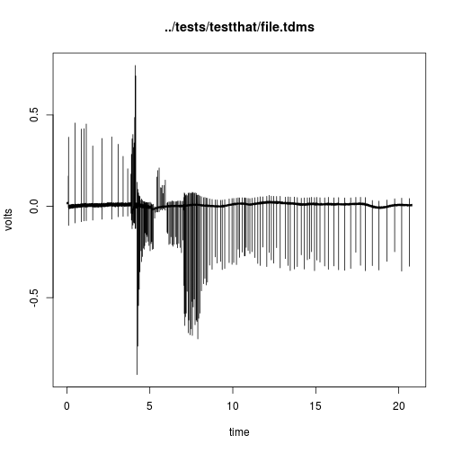

```r
plotTdms('../tests/testthat/file.tdms')
```

Find peaks

```r
p = peakFinder('../tests/testthat/file.tdms')
print(head(p))
```

```
##     peaks direction
## 1 0.08696         +
## 2 0.10198         +
## 3 0.48870         +
## 4 0.87200         +
## 5 1.04231         +
## 6 1.16931         +
```

Look at where the peaks were called

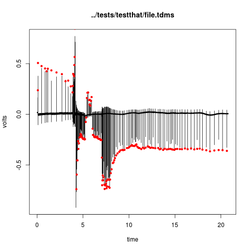

```r
plotTdms('../tests/testthat/file.tdms', peaks = p)
```

Get a matrix of EOD signal

```r
m = getEODMatrix('../tests/testthat/file.tdms', p, prebaseline=T)
print(head(m))
```

```
##         col     time          data
## 1.1 0.08696 -0.00250 -0.0004999497
## 1.2 0.08696 -0.00249 -0.0011577781
## 1.3 0.08696 -0.00248  0.0011446216
## 1.4 0.08696 -0.00247 -0.0008288639
## 1.5 0.08696 -0.00246 -0.0004999497
## 1.6 0.08696 -0.00245  0.0011446216
```

Plot the matrix of EOD signals

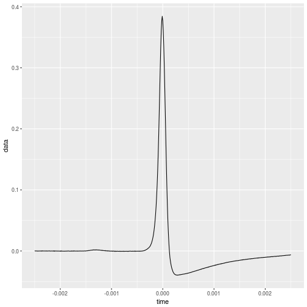

```r
plotAverage(m)
```

Plot all the signals

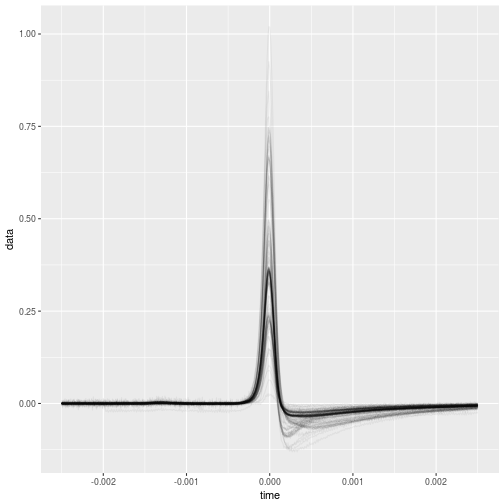

```r
plotTotal(m)
```

```r
landmarks = findLandmarks(m)
print(landmarks)
```

```
##   landmark     time           val          mean          sd
## 1       p0 -0.00068 -7.901732e-04 -7.901732e-04 0.002609323
## 2       p1 -0.00001  3.843618e-01  3.843618e-01 0.175648282
## 3       p2  0.00028 -3.973405e-02 -3.973405e-02 0.021704611
## 4       t1 -0.00025  7.439175e-03  7.439175e-03 0.004501125
## 5       t2  0.00224 -8.381168e-03 -8.381168e-03 0.004497543
## 6       s1 -0.00006  2.601188e-01  2.601188e-01 0.124108301
## 7       s2  0.00005  2.235964e-01  2.235964e-01 0.111163798
## 8      zc1 -0.00039 -1.116577e-05 -1.116577e-05 0.002603257
## 9      zc2  0.00013 -8.529264e-04 -8.529264e-04 0.025507748
```

Plot the landmarks

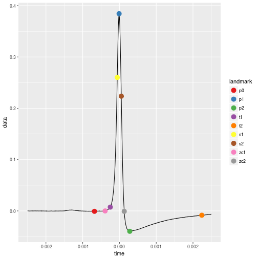

```r
plotLandmarks(m, landmarks)
```

Get stats about the landmarks

```r
getStats(p, landmarks)
```

```
##   amplitude duration total_eods
## 1 0.4240959  0.00249        152
```

### Command line reference

#### `tdmsplot`

```
tdmsplot
Usage: /Users/cdiesh/src/github.com/msuefishlab/eodplotter/inst/scripts/tdmsplot [options]


Options:
    -h, --help
        Show this help message and exit

    -f FILE, --file=FILE
        TDMS file input

    -v VERBOSE, --verbose=VERBOSE
        Print verbose output

    -c CHANNEL, --channel=CHANNEL
        Channel name

    -s START, --start=START
        Start time

    -e END, --end=END
        End time
```

Outputs a file.signal.png file representing the raw signal values of the EODs

#### `peak_finder`

```
Usage: /Users/cdiesh/src/github.com/msuefishlab/eodplotter/inst/scripts/peak_finder [options]

Options:
    -h, --help
        Show this help message and exit

    -f FILE, --file=FILE
        TDMS file input

    -v, --verbose
        Print verbose output

    -c CHANNEL, --channel=CHANNEL
        Channel name

    -n NUMBER, --number=NUMBER
        Peak finder threshold, sigma or voltage threshold

    -d DIRECTION, --direction=DIRECTION
        Direction, enter either positive/negative/none

    -s START, --start=START
        Start time

    -e END, --end=END
        End time

    -r REMOVE, --remove=REMOVE
        Amount to remove from start/end of recording
```

#### `eodplot`

```
Usage: /Users/cdiesh/src/github.com/msuefishlab/eodplotter/inst/scripts/eodplot [options]


Options:
    -h, --help
        Show this help message and exit

    -f FILE, --file=FILE
        TDMS file input

    -p PEAK, --peak=PEAK
        Peak file input

    -v, --verbose
        Print verbose output

    -c CHANNEL, --channel=CHANNEL
        Channel name

    -w WINDOW, --window=WINDOW
        Window size around peak value

    -b, --prebaseline
        Pre-normalization baseline subtract

    -d, --postbaseline
        Post-normalization baseline subtract

    -n, --normalize
        Normalize waveform between 0-1 peak to peak height

    -a ALPHA, --alpha=ALPHA
        Alpha channel for individual peaks
```

Outputs a bunch of files completing the analysis

- file.all.png - a visualization of all EOD signal traces
- file.average.png - the average EOD waveform
- file.average.landmarks.png - the average EOD waveform with landmarks plotted
- file.landmarks.csv - the data on the landmarks detected
- file.stats.csv - the data on duration, amplitude, and number of EODs detected

#### `multieodplot`

```
Usage: /Users/cdiesh/src/github.com/msuefishlab/eodplotter/inst/scripts/multieodplot [options]


Options:
    -h, --help
        Show this help message and exit

    -f FILE, --file=FILE
        TDMS/Peak file table

    -c CHANNEL, --channel=CHANNEL
        Channel name

    -w WINDOW, --window=WINDOW
        Window size around peak value

    -v, --verbose
        Print verbose output

    -b, --prebaseline
        Pre-normalization baseline subtract

    -d, --postbaseline
        Post-normalization baseline subtract

    -n, --normalize
        Normalize waveform between 0-1 peak to peak height

    -a ALPHA, --alpha=ALPHA
        Transparency factor aka alpha channel for plotting EODs

    -p, --pdf
        Use PDF output

    -A, --all
        Plot all traces
```

## Conclusion

This demo shows you how to use the `eodplotter` as an R library. Note that there is the alternative usage of the library using the command line as well, which can be more streamlined